# EDA_funnel_marketing_B2B

**Made By DAHOU RENAUD L. Data Scientist in Benin**

- Whatsapp: +22967927952
- Email: dahou.r@yahoo.com

## **Répertoire de travail**

```python
from google.colab import drive
drive.mount('/content/drive/')
import os
os.chdir("/content/drive/My Drive/DATASCIENCE/Projet/Marketing_project")
```

```python
!jupyter nbconvert --to html EDA_funnel_marketing_B2B.ipynb
```

```python
import warnings
warnings.filterwarnings('ignore')

from datetime import datetime, timedelta,date
import pandas as pd

import matplotlib.pyplot as plt
import numpy as np
import seaborn as sns
from sklearn.cluster import KMeans
```

# **Analyse exploratoire des données d'un funnel marketing B2B**

Ce projet se concentre sur la réalisation D'une analyse exploratoire des données (EDA) pour le Marketing B2B en utilisant Python. Nous utiliserons les données D'Olist, une plate-forme de commerce électronique qui relie les petites et moyennes entreprises aux principaux marchés du Brésil, par exemple. En plus de fournir la méthode et le code, je veux également discuter des principes fondamentaux du Marketing B2B et de la façon dont ces idées EDA peuvent aider Olist à prendre une meilleure décision marketing.

[figure not shown]

### **À propos de cet ensemble de données**

Cet ensemble de données a été généreusement fourni par Olist, le plus grand grand magasin des marchés Brésiliens. Olist relie les petites entreprises de tout le Brésil aux canaux sans tracas et avec un seul contrat. Ces marchands peuvent vendre leurs produits via le magasin Olist et les expédier directement aux clients en utilisant les partenaires logistiques Olist. Voir plus sur notre site web: www.olist.com

Un vendeur se joint à Olist via un entonnoir de marketing et de vente qui a été rendu public dans cet ensemble de données. Description des étapes:

1. Inscrivez-vous à une page de destination.
2. Être contacté par un représentant du développement des ventes (DTS), confirmer certaines informations et planifier une consultation.
3. Le Conseil est effectué par un représentant commercial (SR). Le SR peut fermer la transaction (lead sing up) ou perdre la transaction (LED quitte sans connexion)
4. Lead devient vendeur et commence à construire son catalogue sur Olist.
5. Ses produits sont publiés sur les marchés et prêts à être vendus!

### **Exemples de pages de destination**

[figure not shown]

### **Schéma De Données**

Les données sont divisées en plusieurs ensembles de données pour une meilleure compréhension et organisation. Veuillez vous référer au schéma de données lorsque vous travaillez avec elle:

[figure not shown]

### **Présentation des données**

Les ensembles de données ont été obtenus auprès de Kaggle. Vous pouvez le télécharger [ici](https://www.kaggle.com/olistbr/marketing-funnel-olist/download/pej2DoOHVneC5N7rxJDw%2Fversions%2FtGhVwLrNFEPnXQl62SUe%2Ffiles%2Folist_closed_deals_dataset.csv?datasetVersionNumber=2) .

Le premier ensemble de données a 4 variables avec 8000 points de données. Les variables sont MQL_id (marketing qualified leads), sa date de premier contact, la page de destination qui a capturé les leads et l'origine des leads (le canal qui amène les leads aux pages de destination).

```python
#load dataset
import pandas as pd
mql = pd.read_csv('olist_marketing_qualified_leads_dataset.csv')
mql
```

|  | mql_id | first_contact_date | landing_page_id | origin |
| --- | --- | --- | --- | --- |
| 0 | dac32acd4db4c29c230538b72f8dd87d | 2018-02-01 | 88740e65d5d6b056e0cda098e1ea6313 | social |
| 1 | 8c18d1de7f67e60dbd64e3c07d7e9d5d | 2017-10-20 | 007f9098284a86ee80ddeb25d53e0af8 | paid_search |
| 2 | b4bc852d233dfefc5131f593b538befa | 2018-03-22 | a7982125ff7aa3b2054c6e44f9d28522 | organic_search |
| 3 | 6be030b81c75970747525b843c1ef4f8 | 2018-01-22 | d45d558f0daeecf3cccdffe3c59684aa | email |
| 4 | 5420aad7fec3549a85876ba1c529bd84 | 2018-02-21 | b48ec5f3b04e9068441002a19df93c6c | organic_search |
| ... | ... | ... | ... | ... |
| 7995 | feaba3ffcd2ff97501696c7f9a42f41c | 2018-05-22 | e42a14209c69c3e9cc6b042620465f12 | paid_search |
| 7996 | a79cb53cd009ab92e0143b92baa2407b | 2018-03-27 | c494978688ccf66ad9fad3d6a3338c22 | paid_search |
| 7997 | 68f049a23ab109c6a0f6989bb9a02994 | 2017-08-27 | b48ec5f3b04e9068441002a19df93c6c | organic_search |
| 7998 | 4f8c96e2509b984329044c6682c88ee9 | 2017-10-06 | a56671a54260a44923d32c2f08fad39c | organic_search |
| 7999 | 8a6492305a5fbcdcdd1a7f5a90764c07 | 2018-01-11 | b76ef37428e6799c421989521c0e5077 | direct_traffic |

8000 rows × 4 columns

Le deuxième ensemble de données contient 842 observations avec 14 variables. Chaque observation est une transaction gagnée D'Olist qui se compose du mql_id du marchand, seller_id (utilisé dans la plate-forme Olist), sdr_id et sr_id(le représentant du développement des ventes et le représentant des ventes qui étaient en charge de la transaction), won_date, business segment, lead_type, lead_behaviour_profile, business_type, declared_monthly_revenue. Parmi ceux-ci, 5 variables ont trop de valeurs nulles donc elles ne peuvent pas apporter de valeur à l'analyse.

```python
close = pd.read_csv('olist_closed_deals_dataset.csv')
close
```

|  | mql_id | seller_id | sdr_id | sr_id | won_date | business_segment | lead_type | lead_behaviour_profile | has_company | has_gtin | average_stock | business_type | declared_product_catalog_size | declared_monthly_revenue |
| --- | --- | --- | --- | --- | --- | --- | --- | --- | --- | --- | --- | --- | --- | --- |
| 0 | 5420aad7fec3549a85876ba1c529bd84 | 2c43fb513632d29b3b58df74816f1b06 | a8387c01a09e99ce014107505b92388c | 4ef15afb4b2723d8f3d81e51ec7afefe | 2018-02-26 19:58:54 | pet | online_medium | cat | NaN | NaN | NaN | reseller | NaN | 0.0 |
| 1 | a555fb36b9368110ede0f043dfc3b9a0 | bbb7d7893a450660432ea6652310ebb7 | 09285259593c61296eef10c734121d5b | d3d1e91a157ea7f90548eef82f1955e3 | 2018-05-08 20:17:59 | car_accessories | industry | eagle | NaN | NaN | NaN | reseller | NaN | 0.0 |
| 2 | 327174d3648a2d047e8940d7d15204ca | 612170e34b97004b3ba37eae81836b4c | b90f87164b5f8c2cfa5c8572834dbe3f | 6565aa9ce3178a5caf6171827af3a9ba | 2018-06-05 17:27:23 | home_appliances | online_big | cat | NaN | NaN | NaN | reseller | NaN | 0.0 |
| 3 | f5fee8f7da74f4887f5bcae2bafb6dd6 | 21e1781e36faf92725dde4730a88ca0f | 56bf83c4bb35763a51c2baab501b4c67 | d3d1e91a157ea7f90548eef82f1955e3 | 2018-01-17 13:51:03 | food_drink | online_small | NaN | NaN | NaN | NaN | reseller | NaN | 0.0 |
| 4 | ffe640179b554e295c167a2f6be528e0 | ed8cb7b190ceb6067227478e48cf8dde | 4b339f9567d060bcea4f5136b9f5949e | d3d1e91a157ea7f90548eef82f1955e3 | 2018-07-03 20:17:45 | home_appliances | industry | wolf | NaN | NaN | NaN | manufacturer | NaN | 0.0 |
| ... | ... | ... | ... | ... | ... | ... | ... | ... | ... | ... | ... | ... | ... | ... |
| 837 | df9a2abe2ad3f2d8758b675ac8331ecf | bfcc27719640628da877db48b672b169 | 45749fb708130f78d0db07d8d80f030b | a8387c01a09e99ce014107505b92388c | 2018-08-01 20:22:31 | home_decor | offline | cat | NaN | NaN | NaN | reseller | NaN | 0.0 |
| 838 | 8723201570415eb23b4f095d8c20a27c | 4a82eab98441aeb64566e2776c1fb2b6 | 370c9f455f93a9a96cbe9bea48e70033 | 4b339f9567d060bcea4f5136b9f5949e | 2018-09-27 18:58:41 | construction_tools_house_garden | online_big | wolf | NaN | NaN | NaN | reseller | 132.0 | 200000.0 |
| 839 | 2e57665b8faf05c967a801eb5aedfa0a | 55031883943971ca22db6894574cfe2c | 370c9f455f93a9a96cbe9bea48e70033 | a8387c01a09e99ce014107505b92388c | 2018-06-06 20:15:26 | computers | online_medium | wolf | NaN | NaN | NaN | reseller | NaN | 0.0 |
| 840 | 40955be51cc85c5a5a6cdd12b19e9f10 | c0e933c238e41f0cd459d6025ee9b364 | 068066e24f0c643eb1d089c7dd20cd73 | d3d1e91a157ea7f90548eef82f1955e3 | 2018-03-06 15:52:23 | pet | online_beginner | cat | NaN | NaN | NaN | reseller | NaN | 0.0 |
| 841 | 8a6492305a5fbcdcdd1a7f5a90764c07 | 1bba9c94eb5c4e82fba9f7286fe81025 | 56bf83c4bb35763a51c2baab501b4c67 | de63de0d10a6012430098db33c679b0b | 2018-05-02 13:31:32 | household_utilities | industry | eagle | NaN | NaN | NaN | manufacturer | NaN | 0.0 |

842 rows × 14 columns

Troisième jeu de données: via Kaggle, Olist a également donné son jeu de données sur à propos de la demande. Nous l'utiliserons pour informer les spécialistes du marketing Olist sur les performances des vendeurs, les aidant ainsi à améliorer le processus de marketing B2B. NB: ce jeu de donné n'est plus disponible sur kaggle

```python
#ecommerce data
order_item = pd.read_csv("olist_order_items_dataset.csv")
orders = pd.read_csv("olist_orders_dataset.csv")
product = pd.read_csv("olist_products_dataset.csv")
category = pd.read_csv("product_category_name_translation.csv")
```

## **Analyse Exploratoire Des Données**

Le nombre de MQL: les données MQL (MQL data) sont fournies du 07/2017 au 06/2018, tandis que les données MQL won sont fournies du 01/2018 au 12/2018. En 2017, les MQLs générés par L'équipe marketing D'Olist sont d'environ 400 MQLs / mois. En 2018, ils augmentent le nombre à 1000-1400 prospects par mois. En ce qui concerne le MQL gagné, son pic était à 05/2018 avec 200 opportunités gagnées.

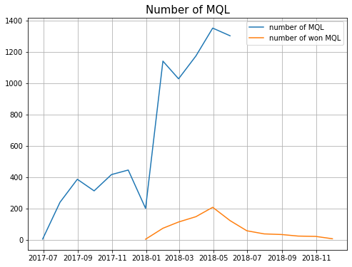

```python
import matplotlib.pyplot as plt
#Figure 1
num_mql = mql.set_index(pd.to_datetime(mql['first_contact_date']))
num_mql = num_mql.groupby(pd.Grouper(freq = "M")).count().drop(axis =1, columns = ['first_contact_date',"landing_page_id", "origin"])
num_won = close.set_index(pd.to_datetime(close["won_date"]))
num_won = num_won.groupby(pd.Grouper(freq = "M")).count().drop(axis = 1, columns = ["seller_id", "sdr_id", "sr_id","business_segment", "lead_type", "lead_behaviour_profile", "has_company", "has_gtin", "average_stock", "business_type","declared_product_catalog_size",
 "declared_monthly_revenue", "won_date"])
plt.figure(figsize = (8,6))
plt.plot(num_mql.index, num_mql, "-", label = "number of MQL")
plt.plot(num_won.index, num_won, "-", label = "number of won MQL")
plt.legend()
plt.grid()
plt.title("Number of MQL", size = 15)
plt.savefig("NumMQL.png")
```

# **Les cannaux**

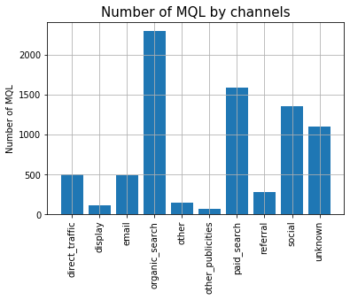

```python
#Figure 3
mql_origin = mql.groupby('origin').agg({'mql_id':"count"})
origin = list(mql_origin.index)

#Number of MQL by channels
plt.figure(figsize = (6,4))
plt.bar(mql_origin.index, mql_origin['mql_id'])
plt.xticks(rotation = 90)
plt.ylabel('Number of MQL')
plt.grid()
plt.title("Number of MQL by channels", size =15)
plt.savefig("channelc-mql.png")
```

[output not shown]

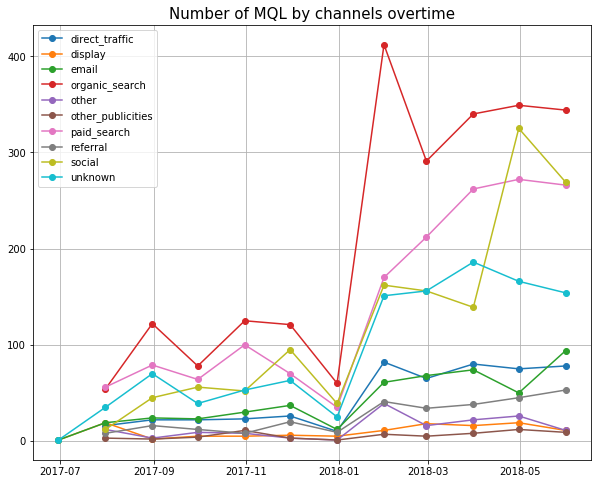

```python
#Figure 4
mql_origin = mql.groupby('origin').agg({'mql_id':"count"});print(mql_origin)
origin = list(mql_origin.index)
plt.figure(figsize = (10,8))
fancy_plot = plt.subplot()
for i in origin:
  channel = mql[mql['origin'] == i]
  channel = channel.set_index(pd.to_datetime(channel['first_contact_date']))
  channel_agg = channel.groupby(pd.Grouper(freq = "M")).count().drop(axis = 1, columns =["first_contact_date",
 "landing_page_id", "origin"])
  fancy_plot.plot(channel_agg.index, channel_agg, "-o", label = i)
fancy_plot.legend()
plt.grid()
plt.title('Number of MQL by channels overtime', size = 15)
plt.savefig("channel-mql.png")
```

## **Taux de conversion**

```python
data = pd.merge(mql, close, how = "left", on = "mql_id")
data['lost'] = data['won_date'].isnull()
```

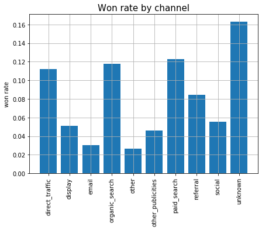

```python
#Figure 5
#Opportunity won rate by channel
data_origin = data[["origin","lost", 'mql_id']]
origin_lost = data_origin.groupby(['origin', 'lost']).count()

percentage = []
for i in origin:
    pct = origin_lost.loc[i].loc[False][0]/(origin_lost.loc[i].loc[True][0]+origin_lost.loc[i].loc[False][0])
    percentage.append(pct)

plt.figure(figsize = (7,5))
plt.bar(origin, percentage)
plt.xticks(rotation = 90)
plt.ylabel('won rate')
plt.grid()
plt.title("Won rate by channel", size = 15)
plt.savefig("Won_rate-mql.png")
```

## **La Page De Destination**

Olist a utilisé 34 pages de destination pour capturer des MQL. Même si l'équipe de vente est responsable de la conversion D'un MQL en une opportunité gagnée, l'équipe de marketing peut affecter cette probabilité du haut de l'entonnoir en fournissant des messages pertinents et des avantages sur les pages de destination. D'après la figure 5 ci-dessous, il y a 2 pages de destination qui ont un nombre très élevé de Mql (800MQL) ainsi qu'un taux de convertion (won_rate) très élevé (~20%), ce qui signifie que 20% des MQL capturés à partir de ces pages de destination deviennent les vendeurs D'Olist.

```python
#Figure 6
mql_lp = mql.groupby('landing_page_id').agg({'mql_id':"count"})
mql_lp = mql_lp[mql_lp['mql_id'] > 30]
data_lp = pd.merge(data, mql_lp, how = "inner", left_on = "landing_page_id", right_index = True)
#ata_lp = data_lp[data_lp['lost']]
lp_lost = data_lp.groupby(['landing_page_id', 'lost']).agg({'mql_id_x':"count"})
landing_page = list(mql_lp.index)

percentage_lp = []
landing_page_2 = []
Num_mql = []
for i in landing_page:
    if mql_lp.loc[i][0] == lp_lost.loc[i].loc[True][0]:
        lp_lost.drop([i])
    else:
        pct = lp_lost.loc[i].loc[False][0]/(lp_lost.loc[i].loc[True][0]+lp_lost.loc[i].loc[False][0])
        percentage_lp.append(pct)
        landing_page_2.append(i)
        Num_mql.append(mql_lp.loc[i][0])
```

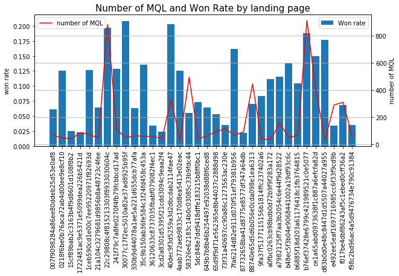

```python
# Landing Page number of MQL and Won rate
fig = plt.figure(figsize = (10,4))
ax = fig.add_subplot(111)
ax2 = ax.twinx()
ax.bar(landing_page_2, percentage_lp, label = "Won rate")
ax2.plot(landing_page_2, Num_mql, color = "red", label = "number of MQL")
ax.set_ylabel('won rate')
ax.legend()
ax2.set_ylabel('number of MQL')
ax2.legend()
plt.grid()
plt.title("Number of MQL and Won Rate by landing page", size = 15)
for tick in ax.get_xticklabels():
    tick.set_rotation(90)
```

l'analyse de ces pages de destination peut aider Olist à reproduire le succès à d'autres pages de destination.

## **Ciblage - segment d'activité**

Le ciblage est très important dans le marketing B2B. Il y a des segments qui seront très intéressés par Olist et vice versa. Le graphique suivant montre qu'en utilisant le cycle de vente (la durée du processus de vente) comme indication:

```python
data2 = pd.merge(mql, close, how = "right", on = "mql_id")

#Turn string into datetime data
data2['first_contact_date'] = pd.to_datetime(data2['first_contact_date'])
data2['won_date'] = pd.to_datetime(data2['won_date'])

#Sales cycle calculation
data2['sales cycle'] = data2['won_date'] - data2['first_contact_date']
data2['sales cycle'] = data2['sales cycle'].dt.days
```

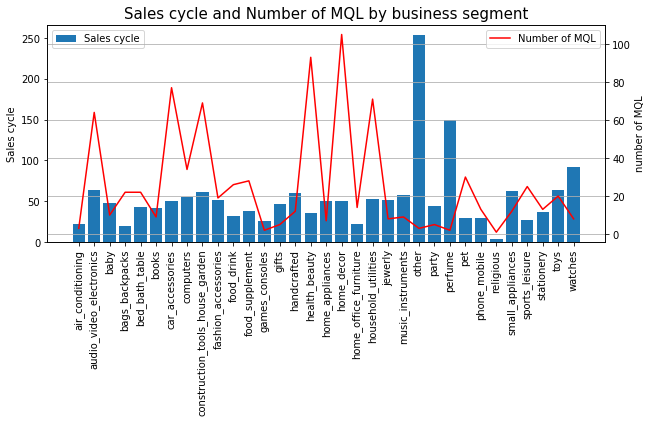

```python
#Figure 7

#sales cycle by Business Segment
segment_time = data2.groupby(['business_segment']).agg({"mql_id":"count", "sales cycle":"mean"})

fig = plt.figure(figsize = (10,4))
ax = fig.add_subplot(111)
ax2 = ax.twinx()
ax.bar(segment_time.index, segment_time['sales cycle'], label = "Sales cycle")
ax2.plot(segment_time.index, segment_time['mql_id'], color = "red", label = "Number of MQL")
ax.set_ylabel('Sales cycle')
ax.legend(loc = "upper left")
plt.title("Sales cycle and Number of MQL by business segment", size =15)
ax2.legend(loc = "upper right")
ax2.set_ylabel('number of MQL')
plt.grid()
for tick in ax.get_xticklabels():
    tick.set_rotation(90)
```

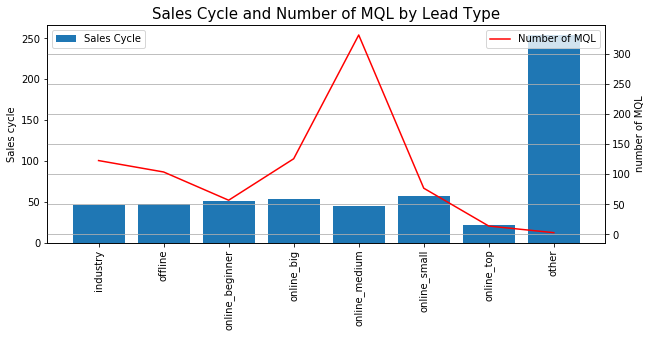

```python
#Figure 8
#Sales cycle by lead type
lead_time = data2.groupby(['lead_type']).agg({"mql_id":"count", "sales cycle":"mean"})

fig = plt.figure(figsize = (10,4))
ax = fig.add_subplot(111)
ax2 = ax.twinx()
ax.bar(lead_time.index, lead_time['sales cycle'], label = "Sales Cycle")
ax2.plot(lead_time.index, lead_time['mql_id'], color = "red", label = "Number of MQL")
ax.set_ylabel('Sales cycle')
ax2.set_ylabel('number of MQL')
ax.legend(loc = "upper left")
ax2.legend(loc = "upper right")
plt.grid()
plt.title("Sales Cycle and Number of MQL by Lead Type", size = 15)
for tick in ax.get_xticklabels():
    tick.set_rotation(90)
```

Olist peut également se baser sur le cycle de vente pour évaluer les performances d'un représentant des ventes. D'après la figure 9, il semble que le nombre de prospects d'un SR soit le plus court du cycle de vente. Cela peut s'expliquer qu'un commercial expérimenté (plus de MQL) sera plus performant (durée de vente plus courte) qu'un nouveau commercial.

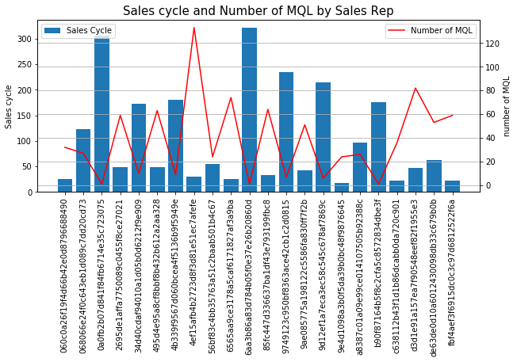

```python
#Figure 9
#Sales cycle by sale reps
sr_time = data2.groupby(['sr_id']).agg({"mql_id":"count", "sales cycle":"mean"})

fig = plt.figure(figsize = (10,4))
ax = fig.add_subplot(111)
ax2 = ax.twinx()
ax.bar(sr_time.index, sr_time['sales cycle'], label = "Sales Cycle")
ax2.plot(sr_time.index, sr_time['mql_id'], color = "red", label = "Number of MQL")
ax.set_ylabel('Sales cycle')
ax2.set_ylabel('number of MQL')
ax.legend(loc = "upper left")
ax2.legend(loc = "upper right")
plt.grid()
plt.title("Sales cycle and Number of MQL by Sales Rep", size = 15)
for tick in ax.get_xticklabels():
    tick.set_rotation(90)
```

### **Profils des prospects**

Le tableau ci-dessous est la description de chaque profil de comportement, basé sur DiSC, un outil d'évaluation du comportement développé à partir de la théorie DiSC du psychologue William Moulton Marston.

- [Cat=Steadiness](https://www.discprofile.com/what-is-disc/overview/)
- [Eagle= Influence](https://www.discprofile.com/what-is-disc/overview/)
- [Wolf=Conscientiousness](https://www.discprofile.com/what-is-disc/overview/)
- [shark=Dominance](https://www.discprofile.com/what-is-disc/overview/)

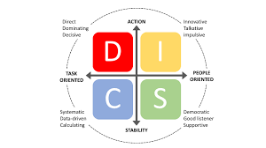

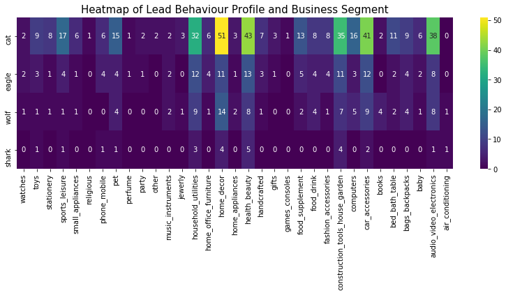

```python
#Figure 10
import seaborn as snb
#The number of MQL by lead behaviour profile and buisness segment
segment = pd.DataFrame(index = ['cat','eagle', 'wolf', 'shark'])
for i in segment_time.index:
    lead_profile = close[close['business_segment'] == i]
    segment = lead_profile.groupby('lead_behaviour_profile').agg({'mql_id':"count"}).rename(columns = {'mql_id':i}).merge(segment,
                                                                                                how = "right", left_index = True, right_index = True)

segment = segment.fillna(0)
plt.figure(figsize = (14,4))
snb.heatmap(segment, annot = True,cmap='viridis')
plt.title("Heatmap of Lead Behaviour Profile and Business Segment", size = 15)
plt.savefig("Lead_Behavior.png")
```

48,3% des profils de comportement de plomb sont constants, ce qui signifie que ces personnes mettent l'accent sur la coopération, la sincérité et la fiabilité. Comprendre les caractéristiques des prospects peut aider l'équipe Olist à créer des personnages pertinents, ce qui leur permet de créer plus facilement des contenus, des messages et des histoires pour le public cible.

### **Type de prospect**

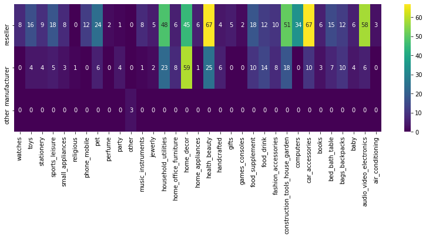

```python
#Figure 11
#Number of MQL by lead type and business segments
segment2 = pd.DataFrame(index = ['reseller', 'manufacturer', 'other'])
for i in segment_time.index:
    lead_profile = close[close['business_segment'] == i]
    segment2 = lead_profile.groupby('business_type').agg({'mql_id':"count"}).rename(columns = {'mql_id':i}).merge(segment2, how = "right", left_index = True, right_index = True)
segment2 = segment2.fillna(0)
plt.figure(figsize = (14,4))
snb.heatmap(segment2, annot = True,cmap='viridis')
plt.savefig("segment_business_type.png")
```

**Voyons à quoi ressemble le troisieme jeu de données sur le e-commerce**.....

```python
#ecommerce data
order_item.head()
```

|  | order_id | order_item_id | product_id | seller_id | shipping_limit_date | price | freight_value |
| --- | --- | --- | --- | --- | --- | --- | --- |
| 0 | 00010242fe8c5a6d1ba2dd792cb16214 | 1 | 4244733e06e7ecb4970a6e2683c13e61 | 48436dade18ac8b2bce089ec2a041202 | 2017-09-19 09:45:35 | 58.90 | 13.29 |
| 1 | 00018f77f2f0320c557190d7a144bdd3 | 1 | e5f2d52b802189ee658865ca93d83a8f | dd7ddc04e1b6c2c614352b383efe2d36 | 2017-05-03 11:05:13 | 239.90 | 19.93 |
| 2 | 000229ec398224ef6ca0657da4fc703e | 1 | c777355d18b72b67abbeef9df44fd0fd | 5b51032eddd242adc84c38acab88f23d | 2018-01-18 14:48:30 | 199.00 | 17.87 |
| 3 | 00024acbcdf0a6daa1e931b038114c75 | 1 | 7634da152a4610f1595efa32f14722fc | 9d7a1d34a5052409006425275ba1c2b4 | 2018-08-15 10:10:18 | 12.99 | 12.79 |
| 4 | 00042b26cf59d7ce69dfabb4e55b4fd9 | 1 | ac6c3623068f30de03045865e4e10089 | df560393f3a51e74553ab94004ba5c87 | 2017-02-13 13:57:51 | 199.90 | 18.14 |

```python
orders.head()
```

|  | order_id | customer_id | order_status | order_purchase_timestamp | order_approved_at | order_delivered_carrier_date | order_delivered_customer_date | order_estimated_delivery_date |
| --- | --- | --- | --- | --- | --- | --- | --- | --- |
| 0 | e481f51cbdc54678b7cc49136f2d6af7 | 9ef432eb6251297304e76186b10a928d | delivered | 2017-10-02 10:56:33 | 2017-10-02 11:07:15 | 2017-10-04 19:55:00 | 2017-10-10 21:25:13 | 2017-10-18 00:00:00 |
| 1 | 53cdb2fc8bc7dce0b6741e2150273451 | b0830fb4747a6c6d20dea0b8c802d7ef | delivered | 2018-07-24 20:41:37 | 2018-07-26 03:24:27 | 2018-07-26 14:31:00 | 2018-08-07 15:27:45 | 2018-08-13 00:00:00 |
| 2 | 47770eb9100c2d0c44946d9cf07ec65d | 41ce2a54c0b03bf3443c3d931a367089 | delivered | 2018-08-08 08:38:49 | 2018-08-08 08:55:23 | 2018-08-08 13:50:00 | 2018-08-17 18:06:29 | 2018-09-04 00:00:00 |
| 3 | 949d5b44dbf5de918fe9c16f97b45f8a | f88197465ea7920adcdbec7375364d82 | delivered | 2017-11-18 19:28:06 | 2017-11-18 19:45:59 | 2017-11-22 13:39:59 | 2017-12-02 00:28:42 | 2017-12-15 00:00:00 |
| 4 | ad21c59c0840e6cb83a9ceb5573f8159 | 8ab97904e6daea8866dbdbc4fb7aad2c | delivered | 2018-02-13 21:18:39 | 2018-02-13 22:20:29 | 2018-02-14 19:46:34 | 2018-02-16 18:17:02 | 2018-02-26 00:00:00 |

```python
product.head()
```

|  | product_id | product_category_name | product_name_lenght | product_description_lenght | product_photos_qty | product_weight_g | product_length_cm | product_height_cm | product_width_cm |
| --- | --- | --- | --- | --- | --- | --- | --- | --- | --- |
| 0 | 1e9e8ef04dbcff4541ed26657ea517e5 | perfumaria | 40.0 | 287.0 | 1.0 | 225.0 | 16.0 | 10.0 | 14.0 |
| 1 | 3aa071139cb16b67ca9e5dea641aaa2f | artes | 44.0 | 276.0 | 1.0 | 1000.0 | 30.0 | 18.0 | 20.0 |
| 2 | 96bd76ec8810374ed1b65e291975717f | esporte_lazer | 46.0 | 250.0 | 1.0 | 154.0 | 18.0 | 9.0 | 15.0 |
| 3 | cef67bcfe19066a932b7673e239eb23d | bebes | 27.0 | 261.0 | 1.0 | 371.0 | 26.0 | 4.0 | 26.0 |
| 4 | 9dc1a7de274444849c219cff195d0b71 | utilidades_domesticas | 37.0 | 402.0 | 4.0 | 625.0 | 20.0 | 17.0 | 13.0 |

```python
category.head()
```

|  | product_category_name | product_category_name_english |
| --- | --- | --- |
| 0 | beleza_saude | health_beauty |
| 1 | informatica_acessorios | computers_accessories |
| 2 | automotivo | auto |
| 3 | cama_mesa_banho | bed_bath_table |
| 4 | moveis_decoracao | furniture_decor |

## **performance de vente conclu**

### **Temps pour les premières commandes**

La plupart des vendeurs doivent attendre moins de 50 jours pour recevoir la première commande D'Olist depuis le jour où ils acceptent de rejoindre la plateforme Olist (figure 12). Les principaux segments d'activité tels que heath_beauty, home_decor,household_utilities, audio_video_electronics, ... attendent généralement 50-60 jours(figure 13) pour avoir la première commande depuis la date gagnée. Nous voyons également d'autres segments tels que food_drink, handcrafted et fashion_accessories ont beaucoup plus de temps avant sa première commande.

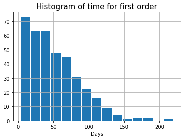

```python
#Figure 12
#Time a seller waits for first order
seller = pd.merge(order_item, orders[['order_id','order_approved_at']], how = "left", left_on = "order_id",right_on = "order_id")
seller['order_approved_at'] = pd.to_datetime(seller['order_approved_at'])

seller_first_order = seller.groupby('seller_id').agg({"order_approved_at":"min"})
diff = pd.merge(close, seller_first_order, how = "inner", left_on = "seller_id", right_index = True)
diff['first_order_time'] = diff['order_approved_at'] - pd.to_datetime(diff['won_date'])
diff['first_order_time'] = diff["first_order_time"].dt.days

#Histogram
plt.figure()
plt.hist(diff["first_order_time"], bins = 15, rwidth = 0.9)
plt.title("Histogram of time for first order",size = 15)
plt.xlabel("Days")
plt.grid()
plt.show()
plt.savefig("first_order_time.png")
```

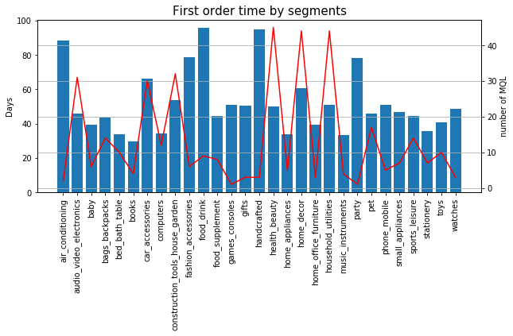

```python
#Figure 13
#Which segment wait the longest time for the first order
first_order_segment = diff.groupby("business_segment").agg({"first_order_time":"mean", "mql_id":"count"})

fig = plt.figure(figsize = (10,4))
ax = fig.add_subplot(111)
ax2 = ax.twinx()
ax.bar(first_order_segment.index, first_order_segment['first_order_time'])
ax2.plot(first_order_segment.index, first_order_segment['mql_id'], color = "red")
ax.set_ylabel('Days')
ax2.set_ylabel('number of MQL')
for tick in ax.get_xticklabels():
    tick.set_rotation(90)
plt.title("First order time by segments", size = 15)
plt.grid()
plt.savefig("First_order_time_by_segments.png")
```

### **Vente réalisé par segment**

La Figure 14 représente les 10 catégories de produits les plus vendues par Olist. Depuis health_beauty, computer_accessories, furniture_devor, housewares, auto, et garden_tools sont également les principaux segments d'affaires parmi MQLs, les valeurs de vente de ces segments également ci-dessus. La seule chose qui me surprend, ce sont les montres. Bien que seulement un petit nombre de vendeurs de montres(8) , les revenus de montres sont vraiment élevées en comparaison avec d'autres segments.

```python
#Top business segments by sales
product = pd.merge(product[["product_id", "product_category_name"]], category, how = "left", left_on = "product_category_name",
                   right_on = "product_category_name")

product_by_value = pd.merge(seller, product, how = "left", left_on = "product_id", right_on = "product_id")

category_sales = product_by_value.groupby("product_category_name_english").agg({"price":"sum"})
category_sales = category_sales.sort_values(by = ["price"], ascending = False)
top10 = category_sales.iloc[:10]
top10_category = top10.index
```

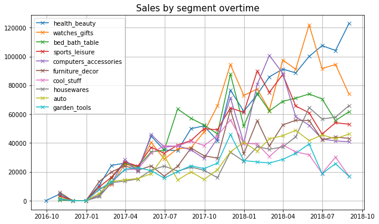

```python
#Figure 14
plt.figure(figsize = (10,6))
fancy_plot_2 = plt.subplot()
for i in top10_category:
    order_category = product_by_value[product_by_value['product_category_name_english'] == i]
    order_category = order_category.set_index(pd.to_datetime(order_category['order_approved_at']))
    order_category_agg = order_category.groupby(pd.Grouper(freq = "M")).agg({"price":"sum"})
    fancy_plot_2.plot(order_category_agg.index, order_category_agg,'-x', label = i)
fancy_plot_2.legend()
plt.title("Sales by segment overtime", size =15)
plt.grid()
plt.savefig("Sales by product category.png")
```

### **Conclusion et recommandation**

Nous avons examiné le marketing des vendeur Olist sous différents angles:

canaux, pages de destination, ciblage (segment d'activité, comportement des prospects, type de prospect, ..), processus de vente (cycle de vente, représentant des ventes), performance de vente conclu

Chaque angle peut ajouter de la valeur à la façon dont l'équipe peut optimiser les campagnes marketing.

Voici quelques recommandations détaillées:

- Continuer à travailler sur le référencement pour augmenter le trafic
- Apprendres des pages de destination à succès pour créer des hypothèses pour les tests A / B. L'objectif est de reproduire les succès dans d'autres pages de destination
- Le segment des loisirs sportifs et des montres peut être développé davantage car Olist peut en tirer des revenus élevés
- Les pistes sont de type stable. Olist peut créer une personnalité client autour de ce type de personnes et créer des messages / contenus pour cibler ces personnes.
- Recherchez dans le segment Home_decor pourquoi il attire de nombreux fabricants. Peut-il être reproduit dans d'autres segments?